# 360-HW2

Safiye Şahin

13 12 2020

For this assignment, 3 different data sets are received from the [Electronic Data Delivery System](https://evds2.tcmb.gov.tr/) , covering the years between 2014-2019 and containing information on a monthly basis. And also a fourth data set is created connected to both of the data sets received by manipulating these data. As a result, a study is conducted examining the relationships of these data and including visual analysis.

A part of the data set is given in the following line to better understand the set. In order to make comparisons easier in the graphs, besides the real value of the exchange rate, it has been modified in order to be close to other data. Also, the dataset has been converted to a time series object and information related to it is provided.

```
## # A tibble: 6 x 7
##   date     year    export    import net_export exchange_rate rexchange_rate
##   <chr>   <dbl>     <dbl>     <dbl>      <dbl>         <dbl>          <dbl>
## 1 2014-01  2014 13056097. 20139261.  -7083164.     22168364.           2.22
## 2 2014-02  2014 13707843. 18829031.  -5121188.     22127600            2.21
## 3 2014-03  2014 15431727. 21284961.  -5853233.     22177952.           2.22
## 4 2014-04  2014 14209641. 21425915.  -7216275.     21274714.           2.13
## 5 2014-05  2014 14460399. 21480371.  -7019972.     20908050            2.09
## 6 2014-06  2014 13554949. 21554236.  -7999287.     21157238.           2.12
```

```
##            export   import net_export rexchange_rate
## Jan 2014 13056097 20139261   -7083164       2.216836
## Feb 2014 13707843 18829031   -5121188       2.212760
## Mar 2014 15431727 21284961   -5853233       2.217795
## Apr 2014 14209641 21425915   -7216275       2.127471
## May 2014 14460399 21480371   -7019972       2.090805
## Jun 2014 13554949 21554236   -7999287       2.115724
```

```
##  The tsdataset series is a mts object with 4 variables and 72 observations
##  Frequency: 12
##  Start time: 2014 1
##  End time: 2019 12
```

## Aim of the Study

There are many factors affecting the foreign trade policies and foreign trade balances of states. Some of these factors can be listed as politically based and some are economically based. If we consider the economy-based factors, the exchange rate may be the first factor that comes to mind. According to the economic theory, if the exchange rate increases, exports increase, imports decrease and thus net exports increase. In this case, the foreign trade balance improves. Otherwise, the relationship proceeds in the opposite direction. In this context this study aims to observe,whether the foreign trade balance of Turkey is affected by the foreign exchange rate changes between 2014 and 2019 in Turkey as in the theory . So the main question of the study is; **Does the change in the exchange rate have an effect on total imports, total exports, and thus on the balance of net exports and foreign economy, as theoretically developed?**

## Visualisations and Analyses of Data

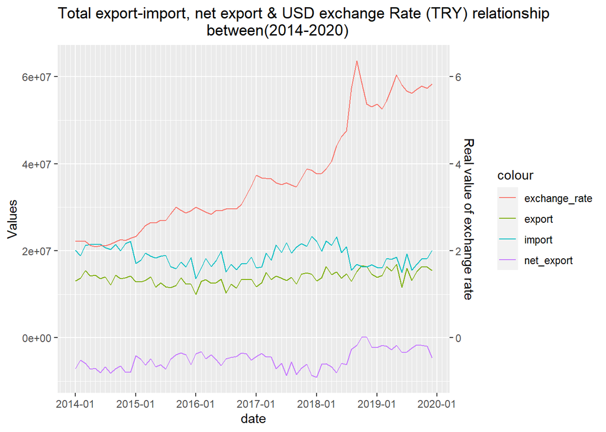

When the graph is examined in a simple way, it can be seen that exports are generally below the imports in the given time period, therefore net exports are at negative values.Also,it can be deduced that the exchange rate has always been in an increasing trend over the years, except for monthly fluctuations.If the relative data movements are compared, it is seen that the exchange rate and exports and net exports are moving in the same direction , whereas import data show an opposite movement to these data.

In order to obtain more detailed information about the data, it may be more beneficial to apply different visualization and analysis methods at this stage. For example, it would be a logical choice to take a look at the histogram graphs in order to obtain the information about the mobility of each data by years and at what intervals it travels.

### Histograms

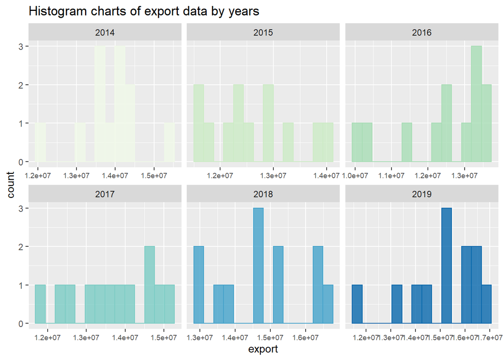

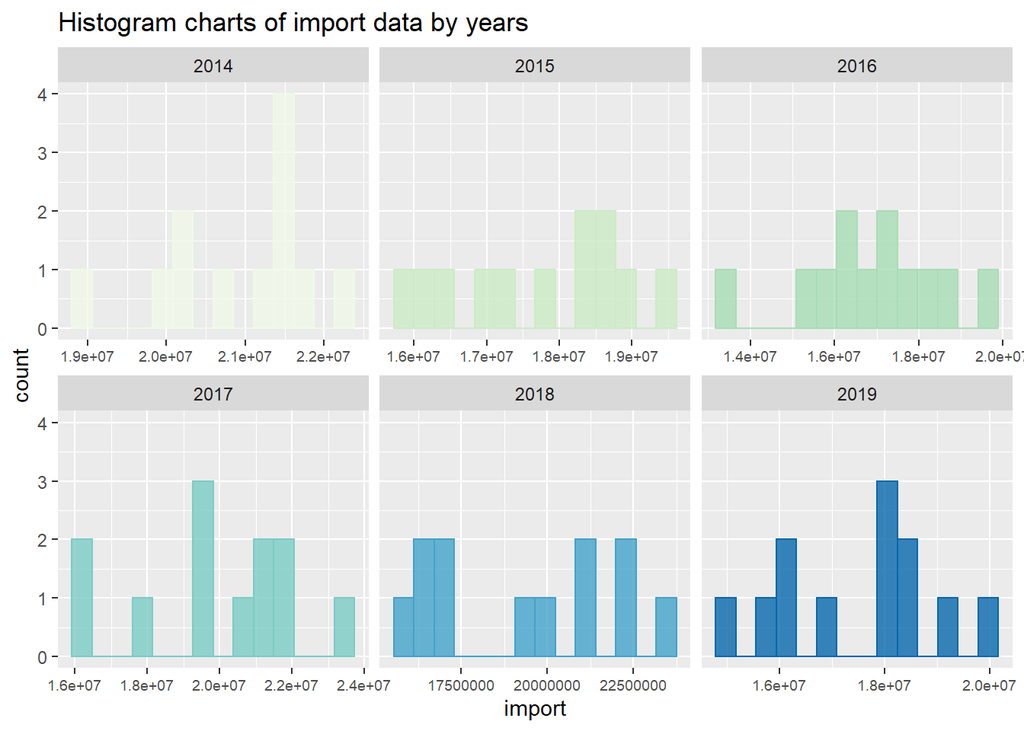

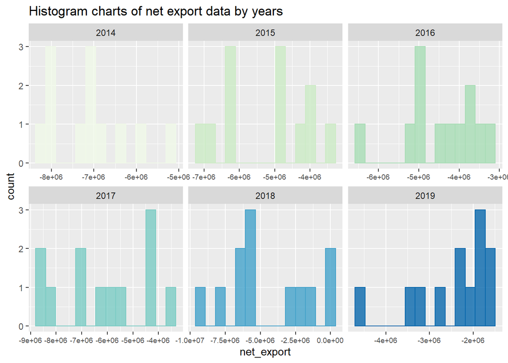

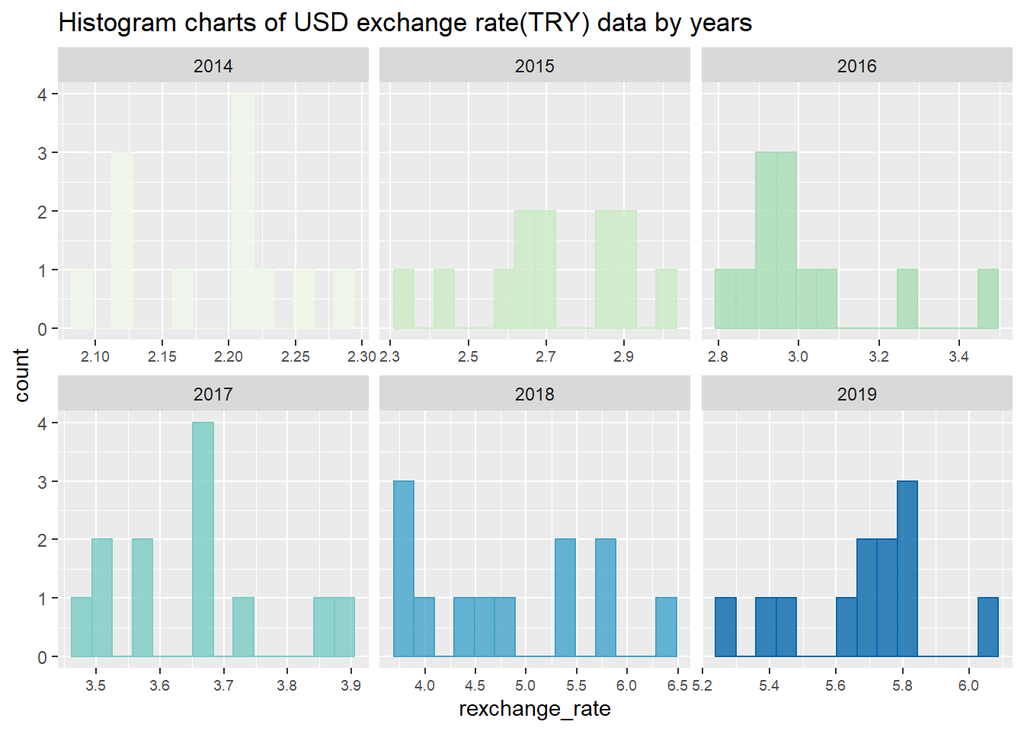

When the distribution of the data in the ranges in the histograms is examined, it can be observed that the imports tend to be more regularly in the ranges especially in 2015 and 2016 , other data are relatively more prone to cluster at certain points.On the other hand, one of the striking data in the analysis is that the difference between the max and min value of the exchange rate in 2018 is much higher than in other years. This difference may indicate that there were sharp fluctuations in the money market during the year, which may be influenced by various factors.Through histograms, information about the distribution trends of the data in the intervals or the width of the gap can be obtained, but examining the data on a single boxplot to compare them with each other will provide better information.

### Boxplot

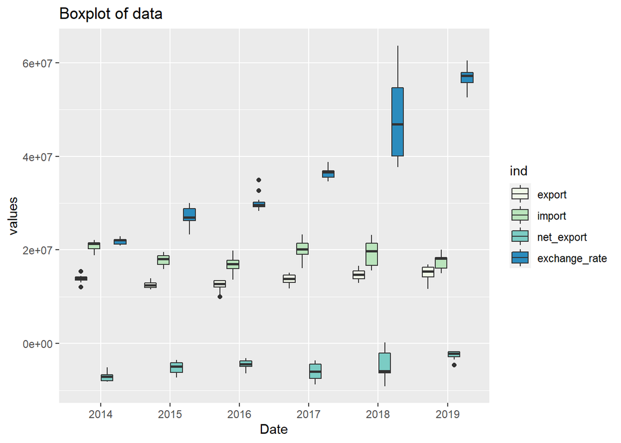

### Pairwise Comparisons

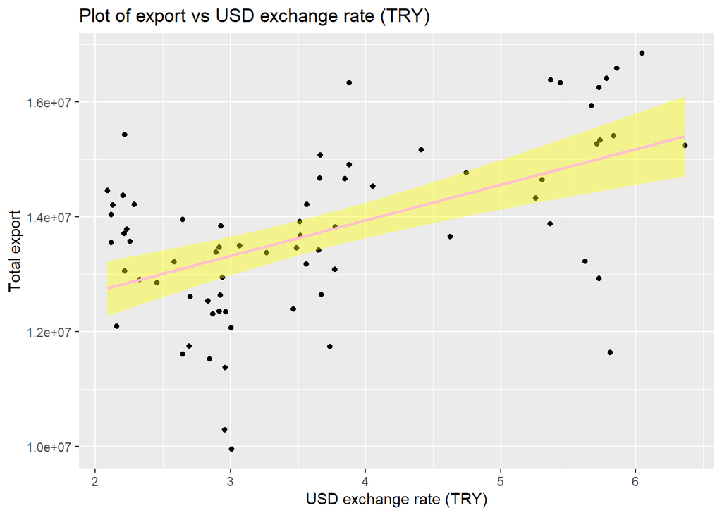

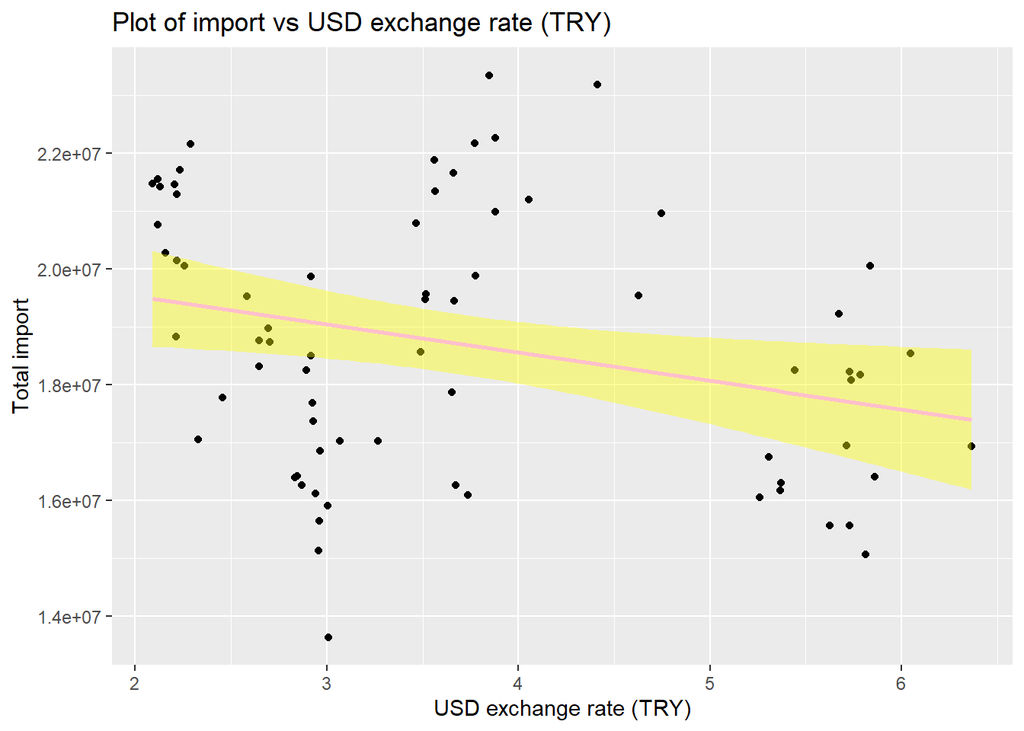

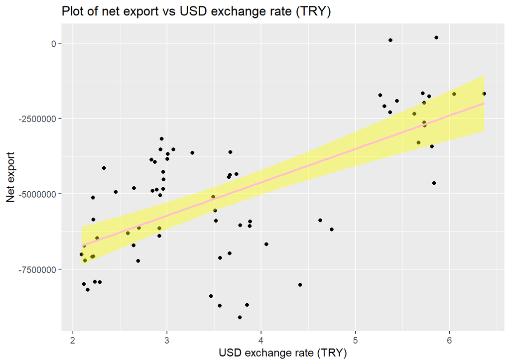

In order to examine the mobility of the data against the exchange rate, drawing their distribution graphs and seeing how their general trends will be will be a good guide for the next step, the correlation phase, where it will analyze to what extent their relationships affect each other.In the first graph, it can be seen that exports are in an upward trend with the increase in exchange rates, and in the second, imports have a decreasing tendency in response to this situation. However, looking at the slopes of the lines, it is seen that the line in the import graph is more horizontal. This shows that imports are not affected by changes in exchange rates as strongly as exports. On the other hand, the line in the graph of net exports has a higher slope than the others, indicating that it is the data most affected by the exchange rate increase. Now conducting correlation analysis to support these interpretations reveals numerical data to support this thesis.

### Correlation Analyses

```
##
##  Pearson's product-moment correlation
##
## data:  new_dataset$export and dataset$rexchange_rate
## t = 5.2577, df = 70, p-value = 7.545e-07
## alternative hypothesis: true correlation is greater than 0
## 95 percent confidence interval:
##  0.3756786 1.0000000
## sample estimates:
##       cor
## 0.5320754
```

```
##
##  Pearson's product-moment correlation
##
## data:  new_dataset$import and dataset$rexchange_rate
## t = -2.3911, df = 70, p-value = 0.9903
## alternative hypothesis: true correlation is greater than 0
## 95 percent confidence interval:
##  -0.4462887  1.0000000
## sample estimates:
##        cor
## -0.2747914
```

```
##
##  Pearson's product-moment correlation
##
## data:  new_dataset$net_export and dataset$rexchange_rate
## t = 7.1135, df = 70, p-value = 3.876e-10
## alternative hypothesis: true correlation is greater than 0
## 95 percent confidence interval:
##  0.5178473 1.0000000
## sample estimates:
##       cor
## 0.6477491
```

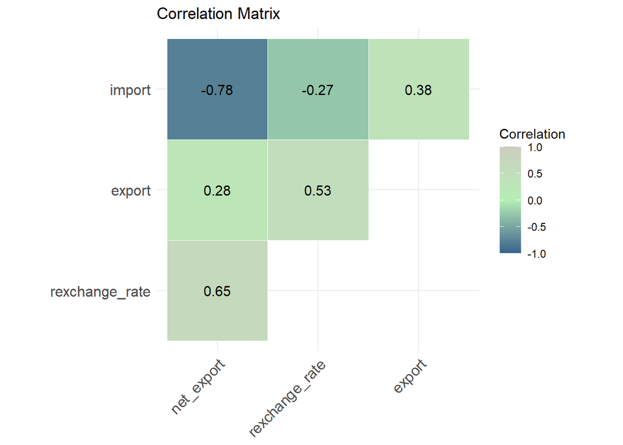